# My First Report

Author

Tyler Ngo

## Welcome to your practice report

This is a **Quarto** document. It mixes ordinary writing with live code, so your report and your analysis always stay in sync. When you click **Render**, Quarto runs the code below and builds a finished HTML page.

Try it now: change `author: "Your Name"` in the header above to your own name, then click **Render**.

## A first look at the data

The code chunk below reads a small practice dataset from the `data/` folder and shows the first few rows.

```r
patients <- read.csv("data/patients.csv") #has dataset as var. "patients"
head(patients)
```

```
  id age sex region systolic_bp diabetes
1  1  54   F  North         128       no
2  2  61   M  North         141      yes
3  3  47   F  South         119       no
4  4  72   M   East         150      yes
5  5  38   F   West         112       no
6  6  59   M  South         134       no
```

## A first chart

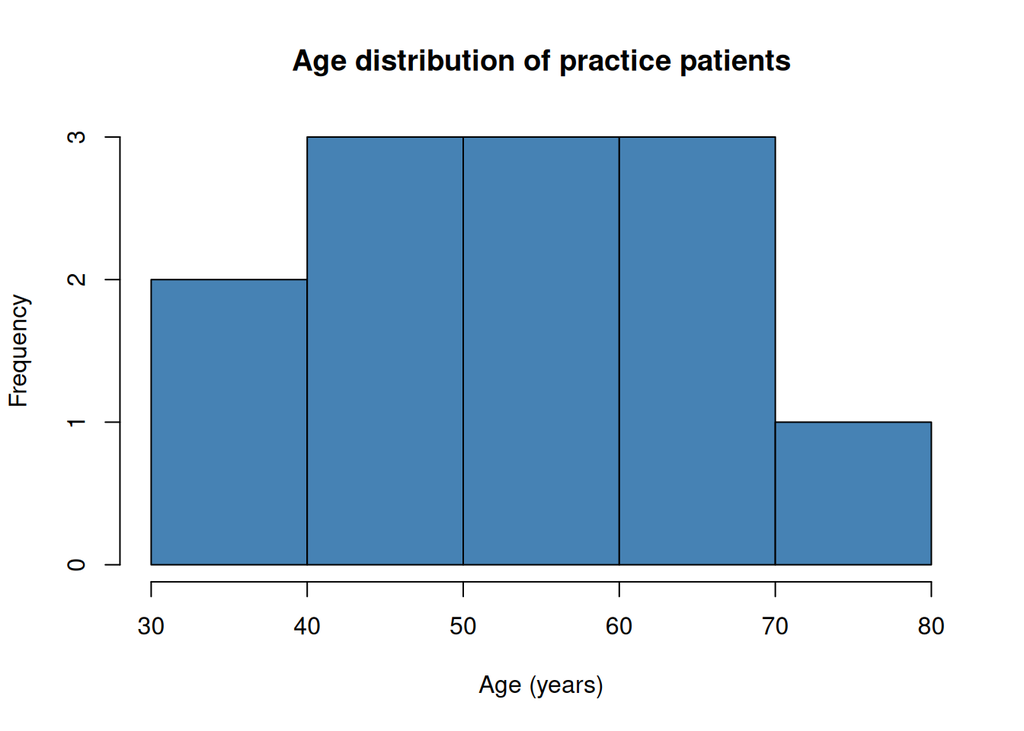

```r
hist(patients$age,
     main = "Age distribution of practice patients",
     xlab = "Age (years)",
     col  = "steelblue")
```

## Your turn

- Within the surveyed population, there was a higher frequency of patients between the ages of 40-70 compared to the frequency of patients in other age groups.
- **AI** was used to explain *error* in opening **Quatro: Preview**, solution was to add file name at the end of the path in the URL chunk as /practice_report.qmd.
- Render again and check that both your sentence and the chart appear.

When you are happy with the result, **commit and sync** your work (the Week 2 course page walks you through this), then submit your repository link on Canvas.